# Reuse

## Looking at the data

There appears to be significant difference in the reuse rate between high and low debt versions.

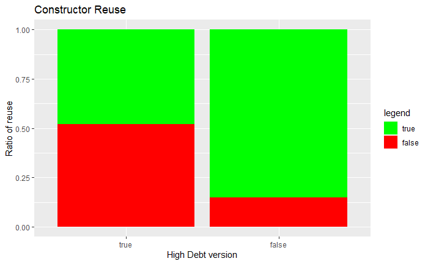

```r
d.completed %>%
  ggplot(aes(high_debt_version)) +
  geom_bar(aes(fill = reused_logic_constructor), position = "fill") +
  scale_fill_manual("legend", values = c("true" = "green", "false" = "red")) +
  labs(title = "Constructor Reuse") +
  xlab("High Debt version") +
  ylab("Ratio of reuse")
```

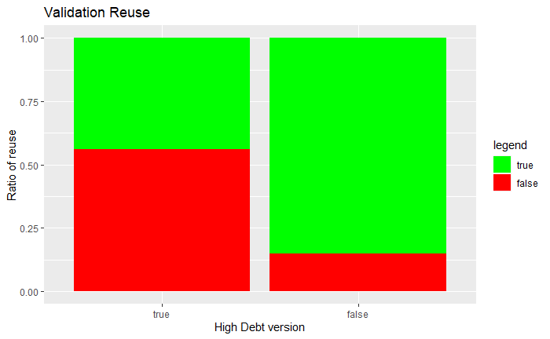

```r
d.completed %>%
  ggplot(aes(high_debt_version)) +
  geom_bar(aes(fill = reused_logic_validation), position = "fill") +
  scale_fill_manual("legend", values = c("true" = "green", "false" = "red")) +
  labs(title = "Validation Reuse") +
  xlab("High Debt version") +
  ylab("Ratio of reuse")
```

## Descriptive Statistics

Full set reuse of constructor:

```r
d.both_completed %>%
  pull(reused_logic_constructor) %>%
  summary()
```

```
 true false
   30    16
```

Full set reuse of validation:

```r
d.both_completed %>%
  pull(reused_logic_validation) %>%
  summary()
```

```
 true false
   29    17
```

## Initial model

For a boolean outcome, bernoulli is the most suitable family.

We include `high_debt_verison` as well as a varying intercept for each individual in our initial model. Since they may correlate, constructor and logic reuse are both included in a single multivariate model.

### Selecting Priors

We iterate over the model until we have sane priors, in this case a prior giving a 50/50 chance was chosen in both cases. The prior “lkj(2)” will mean the model is sceptical of strong correlations.

```r
reuse0.with <- extendable_model(
  base_name = "reuse0",
  base_formula = "mvbind(
    reused_logic_validation,
    reused_logic_constructor
  ) ~ 1 + high_debt_version + (1 |c| session)",
    base_priors = c(
    prior(normal(0, 1), class = "b"),
    prior(normal(0, 1), class = "Intercept"),
    prior(exponential(1), class = "sd", resp = reusedlogicconstructor),
    prior(exponential(1), class = "sd", resp = reusedlogicvalidation),
    prior(lkj(2), class = "L")
  ),
  family = bernoulli(),
  data = d.both_completed,
  base_control = list(adapt_delta = 0.95)
)

# Default priors:
prior_summary(reuse0.with(only_priors= TRUE))
```

```
Setting 'rescor' to FALSE by default for this model
```

```
                prior     class                   coef   group                   resp
               (flat)         b                                reusedlogicconstructor
               (flat)         b high_debt_versionfalse         reusedlogicconstructor
               (flat)         b                                 reusedlogicvalidation
               (flat)         b high_debt_versionfalse          reusedlogicvalidation
 student_t(3, 0, 2.5) Intercept                                reusedlogicconstructor
 student_t(3, 0, 2.5) Intercept                                 reusedlogicvalidation
 lkj_corr_cholesky(1)         L
 lkj_corr_cholesky(1)         L                        session
 student_t(3, 0, 2.5)        sd                                reusedlogicconstructor
 student_t(3, 0, 2.5)        sd                                 reusedlogicvalidation
 student_t(3, 0, 2.5)        sd                        session reusedlogicconstructor
 student_t(3, 0, 2.5)        sd              Intercept session reusedlogicconstructor
 student_t(3, 0, 2.5)        sd                        session  reusedlogicvalidation
 student_t(3, 0, 2.5)        sd              Intercept session  reusedlogicvalidation
 dpar nlpar bound       source
                       default
                  (vectorized)
                       default
                  (vectorized)
                       default
                       default
                       default
                  (vectorized)
                       default
                       default
                  (vectorized)
                  (vectorized)
                  (vectorized)
                  (vectorized)
```

```r
# Our priors:
prior_summary(reuse0.with(sample_prior = "only"))
```

```
Setting 'rescor' to FALSE by default for this model
Specifying global priors for regression coefficients in multivariate models is deprecated. Please specify priors separately for each response variable.Specifying global priors for regression coefficients in multivariate models is deprecated. Please specify priors separately for each response variabl…
```

[output not shown]

[output cut: 240 more lines]

[output not shown]

[output not shown]

[output cut: 73 more lines]

```
 dpar nlpar bound       source
                       default
                  (vectorized)
                       default
                  (vectorized)
                       default
                       default
                          user
                  (vectorized)
                          user
                          user
                  (vectorized)
                  (vectorized)
                  (vectorized)
                  (vectorized)
```

```
Setting 'rescor' to FALSE by default for this model
Specifying global priors for regression coefficients in multivariate models is deprecated. Please specify priors separately for each response variable.Specifying global priors for regression coefficients in multivariate models is deprecated. Please specify priors separately for each response variabl…
```

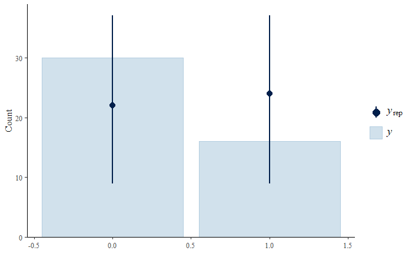

```r
# Prior predictive checks
pp_check(reuse0.with(sample_prior = "only"), type = "bars", nsamples = 200, resp = "reusedlogicconstructor")
```

```
Setting 'rescor' to FALSE by default for this model
Specifying global priors for regression coefficients in multivariate models is deprecated. Please specify priors separately for each response variable.Specifying global priors for regression coefficients in multivariate models is deprecated. Please specify priors separately for each response variabl…
```

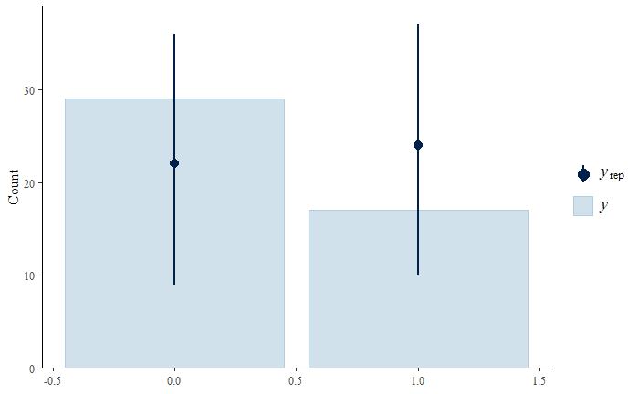

```r
pp_check(reuse0.with(sample_prior = "only"), type = "bars", nsamples = 200, resp = "reusedlogicvalidation")
```

### Model fit

We check the posterior distribution and can see that the model seems to have been able to fit the data well

```
Setting 'rescor' to FALSE by default for this model
Specifying global priors for regression coefficients in multivariate models is deprecated. Please specify priors separately for each response variable.Specifying global priors for regression coefficients in multivariate models is deprecated. Please specify priors separately for each response variabl…
```

[output not shown]

[output cut: 231 more lines]

[output not shown]

[output not shown]

[output cut: 43 more lines]

[output not shown]

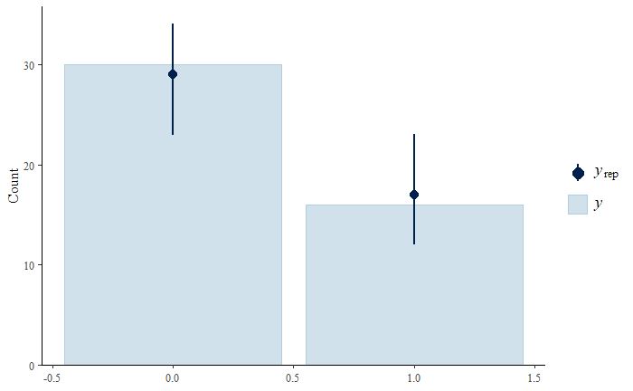

```r
# Posterior predictive check
pp_check(reuse0.with(), type = "bars", nsamples = 200, resp = "reusedlogicconstructor")
```

```
Setting 'rescor' to FALSE by default for this model
Specifying global priors for regression coefficients in multivariate models is deprecated. Please specify priors separately for each response variable.Specifying global priors for regression coefficients in multivariate models is deprecated. Please specify priors separately for each response variabl…
```

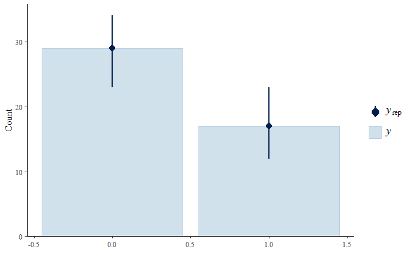

```r
pp_check(reuse0.with(), type = "bars", nsamples = 200, resp = "reusedlogicvalidation")
```

```r
summary(reuse0.with())
```

```
Setting 'rescor' to FALSE by default for this model
Specifying global priors for regression coefficients in multivariate models is deprecated. Please specify priors separately for each response variable.Specifying global priors for regression coefficients in multivariate models is deprecated. Please specify priors separately for each response variabl…
```

```
 Family: MV(bernoulli, bernoulli)
  Links: mu = logit
         mu = logit
Formula: reused_logic_validation ~ 1 + high_debt_version + (1 | c | session)
         reused_logic_constructor ~ 1 + high_debt_version + (1 | c | session)
   Data: as.data.frame(data) (Number of observations: 46)
Samples: 4 chains, each with iter = 2000; warmup = 1000; thin = 1;
         total post-warmup samples = 4000

Group-Level Effects:
~session (Number of levels: 23)
                                                                      Estimate
sd(reusedlogicvalidation_Intercept)                                       1.92
sd(reusedlogicconstructor_Intercept)                                      2.05
cor(reusedlogicvalidation_Intercept,reusedlogicconstructor_Intercept)     0.74
                                                                      Est.Error
sd(reusedlogicvalidation_Intercept)                                        0.79
sd(reusedlogicconstructor_Intercept)                                       0.85
cor(reusedlogicvalidation_Intercept,reusedlogicconstructor_Intercept)      0.22
                                                                      l-95% CI
sd(reusedlogicvalidation_Intercept)                                       0.56
sd(reusedlogicconstructor_Intercept)                                      0.60
cor(reusedlogicvalidation_Intercept,reusedlogicconstructor_Intercept)     0.21
                                                                      u-95% CI Rhat
sd(reusedlogicvalidation_Intercept)                                       3.64 1.00
sd(reusedlogicconstructor_Intercept)                                      3.99 1.00
cor(reusedlogicvalidation_Intercept,reusedlogicconstructor_Intercept)     0.97 1.00
                                                                      Bulk_ESS
sd(reusedlogicvalidation_Intercept)                                        809
sd(reusedlogicconstructor_Intercept)                                      1426
cor(reusedlogicvalidation_Intercept,reusedlogicconstructor_Intercept)      957
                                                                      Tail_ESS
sd(reusedlogicvalidation_Intercept)                                        432
sd(reusedlogicconstructor_Intercept)                                       919
cor(reusedlogicvalidation_Intercept,reusedlogicconstructor_Intercept)      517

Population-Level Effects:
                                              Estimate Est.Error l-95% CI u-95% CI
reusedlogicvalidation_Intercept                   0.27      0.58    -0.82     1.48
reusedlogicconstructor_Intercept                  0.06      0.60    -1.08     1.26
reusedlogicvalidation_high_debt_versionfalse     -1.73      0.66    -3.11    -0.52
reusedlogicconstructor_high_debt_versionfalse    -1.59      0.68    -3.00    -0.31
                                              Rhat Bulk_ESS Tail_ESS
reusedlogicvalidation_Intercept               1.00     2863     3271
reusedlogicconstructor_Intercept              1.00     3746     3128
reusedlogicvalidation_high_debt_versionfalse  1.00     4066     2795
reusedlogicconstructor_high_debt_versionfalse 1.00     4694     2917

Samples were drawn using sample(hmc). For each parameter, Bulk_ESS
and Tail_ESS are effective sample size measures, and Rhat is the potential
scale reduction factor on split chains (at convergence, Rhat = 1).
```

## Model extenstions

```r
summary(reuse0.with("work_domain"))
```

```r
summary(reuse0.with("work_experience_programming.s"))
```

```r
summary(reuse0.with("work_experience_java.s"))
```

```r
summary(reuse0.with("education_field"))
```

```r
summary(reuse0.with(
  "mo(education_level)",
  c(
    prior(dirichlet(2), class = "simo", coef = "moeducation_level1", resp = "reusedlogicconstructor"),
    prior(dirichlet(2), class = "simo", coef = "moeducation_level1", resp = "reusedlogicvalidation")
  )
))
```

```r
summary(reuse0.with("workplace_peer_review"))
```

```r
summary(reuse0.with("workplace_td_tracking"))
```

```r
summary(reuse0.with("workplace_pair_programming"))
```

```r
summary(reuse0.with("workplace_coding_standards"))
```

```r
summary(reuse0.with("scenario"))
```

```r
summary(reuse0.with("group"))
```

Comparing some extensions with loo.

```r
loo(
  reuse0.with(),
  reuse0.with("work_domain"),
  reuse0.with("work_experience_programming.s"),
  reuse0.with("work_experience_java.s"),
  reuse0.with("education_field"),
  reuse0.with(
  "mo(education_level)",
    c(
    prior(dirichlet(2), class = "simo", coef = "moeducation_level1", resp = "reusedlogicconstructor"),
    prior(dirichlet(2), class = "simo", coef = "moeducation_level1", resp = "reusedlogicvalidation")
  )
  ),
  reuse0.with("workplace_peer_review"),
  reuse0.with("workplace_td_tracking"),
  reuse0.with("workplace_pair_programming"),
  reuse0.with("workplace_coding_standards"),
  reuse0.with("scenario"),
  reuse0.with("group"),
  reuse0.with(
  c("work_domain",
    "work_experience_programming.s",
    "work_experience_java.s",
    "education_field",
    "mo(education_level)",
    "workplace_peer_review",
    "workplace_td_tracking",
    "workplace_pair_programming",
    "workplace_coding_standards",
    "scenario",
    "group"
    ),
    c(
    prior(dirichlet(2), class = "simo", coef = "moeducation_level1", resp = "reusedlogicconstructor"),
    prior(dirichlet(2), class = "simo", coef = "moeducation_level1", resp = "reusedlogicvalidation")
  )
)
)
```

[output not shown]

[output not shown]

[output cut: 266 more lines]

[output not shown]

[output not shown]

[output cut: 43 more lines]

[output not shown]

[output not shown]

```
Output of model 'reuse0.with()':

Computed from 4000 by 46 log-likelihood matrix
```

|  | Estimate | SE |
| --- | --- | --- |
| elpd_loo | -45.8 | 4.0 |
| p_loo | 19.6 | 2.0 |
| looic | 91.5 | 7.9 |

```
------
Monte Carlo SE of elpd_loo is NA.

Pareto k diagnostic values:
                         Count Pct.    Min. n_eff
(-Inf, 0.5]   (good)     20    43.5%   428
 (0.5, 0.7]   (ok)       17    37.0%   467
   (0.7, 1]   (bad)       9    19.6%   138
   (1, Inf)   (very bad)  0     0.0%   <NA>
See help('pareto-k-diagnostic') for details.

Output of model 'reuse0.with("work_domain")':

Computed from 4000 by 46 log-likelihood matrix
```

|  | Estimate | SE |
| --- | --- | --- |
| elpd_loo | -47.0 | 4.3 |
| p_loo | 20.6 | 2.2 |
| looic | 94.0 | 8.5 |

```
------
Monte Carlo SE of elpd_loo is NA.

Pareto k diagnostic values:
                         Count Pct.    Min. n_eff
(-Inf, 0.5]   (good)     25    54.3%   420
 (0.5, 0.7]   (ok)       14    30.4%   224
   (0.7, 1]   (bad)       7    15.2%   124
   (1, Inf)   (very bad)  0     0.0%   <NA>
See help('pareto-k-diagnostic') for details.

Output of model 'reuse0.with("work_experience_programming.s")':

Computed from 4000 by 46 log-likelihood matrix
```

|  | Estimate | SE |
| --- | --- | --- |
| elpd_loo | -45.8 | 4.2 |
| p_loo | 20.4 | 2.2 |
| looic | 91.6 | 8.4 |

```
------
Monte Carlo SE of elpd_loo is NA.

Pareto k diagnostic values:
                         Count Pct.    Min. n_eff
(-Inf, 0.5]   (good)     22    47.8%   508
 (0.5, 0.7]   (ok)       16    34.8%   361
   (0.7, 1]   (bad)       8    17.4%   210
   (1, Inf)   (very bad)  0     0.0%   <NA>
See help('pareto-k-diagnostic') for details.

Output of model 'reuse0.with("work_experience_java.s")':

Computed from 4000 by 46 log-likelihood matrix
```

|  | Estimate | SE |
| --- | --- | --- |
| elpd_loo | -45.7 | 4.2 |
| p_loo | 20.5 | 2.1 |
| looic | 91.4 | 8.3 |

```
------
Monte Carlo SE of elpd_loo is NA.

Pareto k diagnostic values:
                         Count Pct.    Min. n_eff
(-Inf, 0.5]   (good)     17    37.0%   535
 (0.5, 0.7]   (ok)       17    37.0%   373
   (0.7, 1]   (bad)      12    26.1%   231
   (1, Inf)   (very bad)  0     0.0%   <NA>
See help('pareto-k-diagnostic') for details.

Output of model 'reuse0.with("education_field")':

Computed from 4000 by 46 log-likelihood matrix
```

|  | Estimate | SE |
| --- | --- | --- |
| elpd_loo | -45.6 | 4.0 |
| p_loo | 20.1 | 2.0 |
| looic | 91.3 | 8.0 |

```
------
Monte Carlo SE of elpd_loo is NA.

Pareto k diagnostic values:
                         Count Pct.    Min. n_eff
(-Inf, 0.5]   (good)     26    56.5%   433
 (0.5, 0.7]   (ok)       15    32.6%   490
   (0.7, 1]   (bad)       5    10.9%   175
   (1, Inf)   (very bad)  0     0.0%   <NA>
See help('pareto-k-diagnostic') for details.

Output of model 'reuse0.with("mo(education_level)", c(prior(dirichlet(2), class = "simo",     coef = "moeducation_level1", resp = "reusedlogicconstructor"),     prior(dirichlet(2), class = "simo", coef = "moeducation_level1",         resp = "reusedlogicvalidation")))':

Computed from 4000 by 46 log-likelihood matrix
```

|  | Estimate | SE |
| --- | --- | --- |
| elpd_loo | -46.2 | 4.4 |
| p_loo | 21.2 | 2.3 |
| looic | 92.4 | 8.7 |

```
------
Monte Carlo SE of elpd_loo is NA.

Pareto k diagnostic values:
                         Count Pct.    Min. n_eff
(-Inf, 0.5]   (good)     20    43.5%   661
 (0.5, 0.7]   (ok)       19    41.3%   350
   (0.7, 1]   (bad)       6    13.0%   76
   (1, Inf)   (very bad)  1     2.2%   103
See help('pareto-k-diagnostic') for details.

Output of model 'reuse0.with("workplace_peer_review")':

Computed from 4000 by 46 log-likelihood matrix
```

|  | Estimate | SE |
| --- | --- | --- |
| elpd_loo | -45.8 | 4.1 |
| p_loo | 20.3 | 2.1 |
| looic | 91.5 | 8.1 |

```
------
Monte Carlo SE of elpd_loo is NA.

Pareto k diagnostic values:
                         Count Pct.    Min. n_eff
(-Inf, 0.5]   (good)     22    47.8%   978
 (0.5, 0.7]   (ok)       16    34.8%   312
   (0.7, 1]   (bad)       8    17.4%   98
   (1, Inf)   (very bad)  0     0.0%   <NA>
See help('pareto-k-diagnostic') for details.

Output of model 'reuse0.with("workplace_td_tracking")':

Computed from 4000 by 46 log-likelihood matrix
```

|  | Estimate | SE |
| --- | --- | --- |
| elpd_loo | -45.4 | 4.0 |
| p_loo | 20.2 | 2.1 |
| looic | 90.9 | 8.1 |

```
------
Monte Carlo SE of elpd_loo is NA.

Pareto k diagnostic values:
                         Count Pct.    Min. n_eff
(-Inf, 0.5]   (good)     17    37.0%   696
 (0.5, 0.7]   (ok)       19    41.3%   288
   (0.7, 1]   (bad)      10    21.7%   92
   (1, Inf)   (very bad)  0     0.0%   <NA>
See help('pareto-k-diagnostic') for details.

Output of model 'reuse0.with("workplace_pair_programming")':

Computed from 4000 by 46 log-likelihood matrix
```

|  | Estimate | SE |
| --- | --- | --- |
| elpd_loo | -44.7 | 3.8 |
| p_loo | 18.6 | 1.8 |
| looic | 89.3 | 7.6 |

```
------
Monte Carlo SE of elpd_loo is NA.

Pareto k diagnostic values:
                         Count Pct.    Min. n_eff
(-Inf, 0.5]   (good)     22    47.8%   540
 (0.5, 0.7]   (ok)       17    37.0%   283
   (0.7, 1]   (bad)       7    15.2%   468
   (1, Inf)   (very bad)  0     0.0%   <NA>
See help('pareto-k-diagnostic') for details.

Output of model 'reuse0.with("workplace_coding_standards")':

Computed from 4000 by 46 log-likelihood matrix
```

|  | Estimate | SE |
| --- | --- | --- |
| elpd_loo | -45.2 | 4.0 |
| p_loo | 19.7 | 2.0 |
| looic | 90.3 | 8.0 |

```
------
Monte Carlo SE of elpd_loo is NA.

Pareto k diagnostic values:
                         Count Pct.    Min. n_eff
(-Inf, 0.5]   (good)     23    50.0%   364
 (0.5, 0.7]   (ok)       17    37.0%   374
   (0.7, 1]   (bad)       6    13.0%   93
   (1, Inf)   (very bad)  0     0.0%   <NA>
See help('pareto-k-diagnostic') for details.

Output of model 'reuse0.with("scenario")':

Computed from 4000 by 46 log-likelihood matrix
```

|  | Estimate | SE |
| --- | --- | --- |
| elpd_loo | -45.8 | 4.0 |
| p_loo | 20.5 | 2.0 |
| looic | 91.5 | 8.0 |

```
------
Monte Carlo SE of elpd_loo is NA.

Pareto k diagnostic values:
                         Count Pct.    Min. n_eff
(-Inf, 0.5]   (good)     21    45.7%   552
 (0.5, 0.7]   (ok)       16    34.8%   298
   (0.7, 1]   (bad)       8    17.4%   192
   (1, Inf)   (very bad)  1     2.2%   101
See help('pareto-k-diagnostic') for details.

Output of model 'reuse0.with("group")':

Computed from 4000 by 46 log-likelihood matrix
```

|  | Estimate | SE |
| --- | --- | --- |
| elpd_loo | -45.3 | 4.0 |
| p_loo | 20.0 | 2.1 |
| looic | 90.5 | 8.0 |

```
------
Monte Carlo SE of elpd_loo is NA.

Pareto k diagnostic values:
                         Count Pct.    Min. n_eff
(-Inf, 0.5]   (good)     25    54.3%   638
 (0.5, 0.7]   (ok)       15    32.6%   294
   (0.7, 1]   (bad)       6    13.0%   194
   (1, Inf)   (very bad)  0     0.0%   <NA>
See help('pareto-k-diagnostic') for details.

Output of model 'reuse0.with(c("work_domain", "work_experience_programming.s",     "work_experience_java.s", "education_field", "mo(education_level)",     "workplace_peer_review", "workplace_td_tracking", "workplace_pair_programming",     "workplace_coding_standards", "scenario", "group"), c(prior(d…

Computed from 4000 by 46 log-likelihood matrix
```

|  | Estimate | SE |
| --- | --- | --- |
| elpd_loo | -50.1 | 4.8 |
| p_loo | 25.3 | 2.8 |
| looic | 100.2 | 9.6 |

[output not shown]

[output cut: 14 more lines]